SYS 6018 | Spring 2024 | University of Virginia

# Homework #10: Clustering

Author

Published

April 30, 2024

# Required R packages and Directories

```r
data_dir = '~/School/Data Mining/Data' # data directory
library(mclust)    # for model-based clustering
library(mixtools)  # for poisson mixture mode
library(tidyverse) # functions for data manipulation
```

# Problem 1: Customer Segmentation with RFM (Recency, Frequency, and Monetary Value)

RFM analysis is an approach that some businesses use to understand their customers’ activities. At any point in time, a company can measure how recently a customer purchased a product (Recency), how many times they purchased a product (Frequency), and how much they have spent (Monetary Value). There are many ad-hoc attempts to segment/cluster customers based on the RFM scores (e.g., here is one based on using the customers’ rank of each dimension independently: https://joaocorreia.io/blog/rfm-analysis-increase-sales-by-segmenting-your-customers.html). In this problem you will use the clustering methods we covered in class to segment the customers.

The data for this problem can be found here: <~/School/Data Mining/Data/RFM.csv>. Cluster based on the Recency, Frequency, and Monetary value columns.

```r
data = read_csv("~/School/Data Mining/Data/RFM.csv")
```

## a. Implement hierarchical clustering.

- Describe any pre-processing steps you took (e.g., scaling, distance metric)
- State the linkage method you used with justification.
- Show the resulting dendrogram
- State the number of segments/clusters you used with justification.
- Using your segmentation, are customers 1 and 100 in the same cluster?

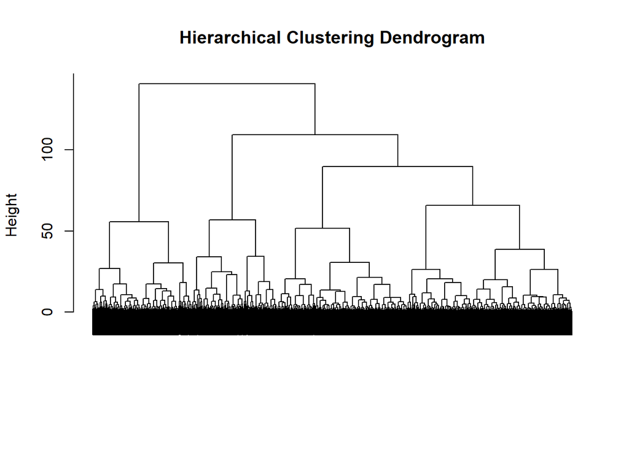

```r
data_scaled = as.data.frame(scale(data))
# Used ward.D2 linkage to increase sum of squares since we're trying to determine the like characteristics for the separate groups
data_hc = hclust(dist(data_scaled), method = "ward.D2")
plot(data_hc, labels = FALSE, main = "Hierarchical Clustering Dendrogram", sub = "", xlab = "")
```

```r
clusters = cutree(data_hc, k = 4)
data$Cluster = clusters

data$CustomerID = 1:nrow(data)

# Check cluster membership
if (nrow(data) >= 100) {  # Ensure there are at least 100 customers
  same_cluster = data$Cluster[1] == data$Cluster[100]
  print(paste("Customer 1 and Customer 100 are in the same cluster:", same_cluster))
} else {
  print("Not enough customers to check customers 1 and 100.")
}
```

```
[1] "Customer 1 and Customer 100 are in the same cluster: TRUE"
```